# bork

Luffy

2017/4/26

```r
knitr::opts_chunk$set(echo = TRUE)
library(knitr)
library(ggplot2)
library(dplyr)
load("books_month_unique.RData")
load("month_merge2.RData")
load("type_info.RData")
load("house_info.RData")
```

```r
summary(house_info)
```

```
##      url                  name           num
##  Length:3281        八方    :   2   Min.   :    1.0
##  Class :character   出色文化:   2   1st Qu.:    2.0
##  Mode  :character   頂淵文化:   2   Median :   11.0
##                     鼎茂    :   2   Mean   :  116.3
##                     耕林    :   2   3rd Qu.:   61.0
##                     桂冠    :   2   Max.   :33156.0
##                     (Other) :3269
```

出版社會有兩家名字一樣嗎？

```r
house <- house_info %>% group_by(name) %>% summarise(count=n()) %>% arrange(desc(count))
house
```

```
## # A tibble: 3,250 × 2
##                  name count
##                <fctr> <int>
## 1                八方     2
## 2            出色文化     2
## 3            頂淵文化     2
## 4                鼎茂     2
## 5                耕林     2
## 6                桂冠     2
## 7  國家通訊傳播委員會     2
## 8            洪葉文化     2
## 9            華泰文化     2
## 10   嘉義市立文化中心     2
## # ... with 3,240 more rows
```

```r
#出版社的出書數量
house <- house_info %>% group_by(name) %>% arrange(desc(num))
house
```

```
## Source: local data frame [3,281 x 3]
## Groups: name [3,250]
##
##                                                                            url
##                                                                          <chr>
## 1   http://www.books.com.tw/web/sys_puballb/books/?pubid=tongli&loc=P_012_1332
## 2  http://www.books.com.tw/web/sys_puballb/books/?pubid=everglory&loc=P_012_11
## 3      http://www.books.com.tw/web/sys_puballb/books/?pubid=gch&loc=P_012_2799
## 4  http://www.books.com.tw/web/sys_puballb/books/?pubid=sharppnt&loc=P_012_848
## 5     http://www.books.com.tw/web/sys_puballb/books/?pubid=homer&loc=P_012_521
## 6  http://www.books.com.tw/web/sys_puballb/books/?pubid=kadokawa&loc=P_012_536
## 7  http://www.books.com.tw/web/sys_puballb/books/?pubid=chingwin&loc=P_012_114
## 8      http://www.books.com.tw/web/sys_puballb/books/?pubid=acme&loc=P_012_460
## 9    http://www.books.com.tw/web/sys_puballb/books/?pubid=sanmin&loc=P_012_164
## 10   http://www.books.com.tw/web/sys_puballb/books/?pubid=taigu1&loc=P_012_055
## # ... with 3,271 more rows, and 2 more variables: name <fctr>, num <dbl>
```

東立出書數明顯大於其他出版社

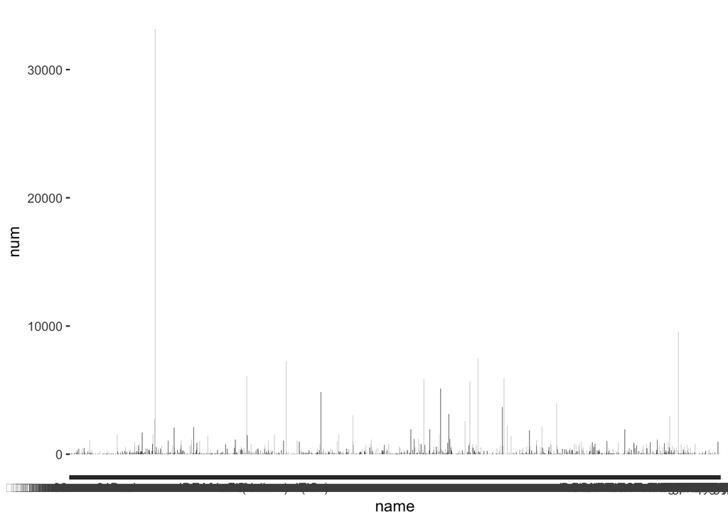

```r
g <- ggplot(house,aes(x=name,y=num))
g + geom_bar(stat = "identity")
```

那條長長的就是東立。

去掉東立這個outluier看看

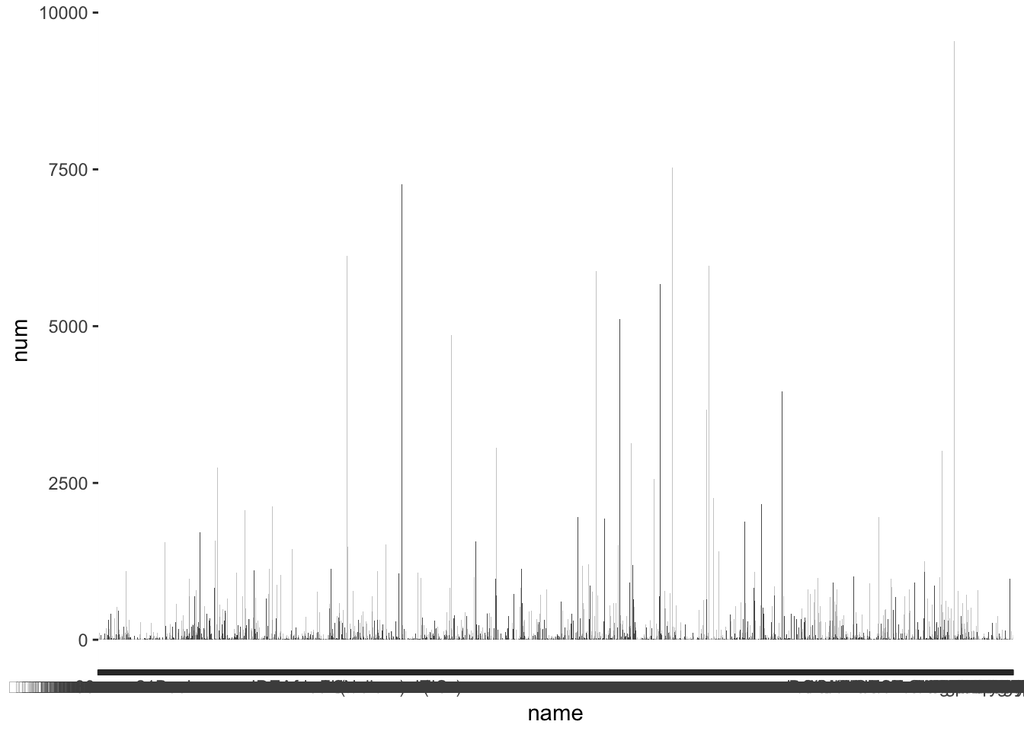

```r
house <- house_info %>% group_by(name) %>% arrange(desc(num)) %>%filter(num<30000)
g <- ggplot(house,aes(x=name,y=num))
g + geom_bar(stat = "identity")
```

[figure not shown]

```r
pie(house_info$num, labels = house_info$name, main="Pie Chart ")
```

大部分的出版社佔比都很小…

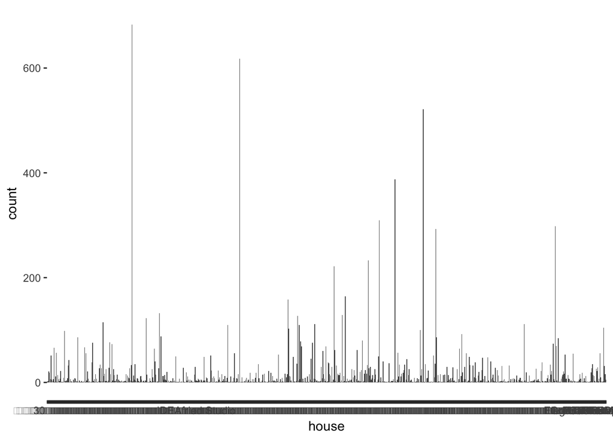

```r
#各出版社的進榜書數(unique)
qplot(house, data=df_books_month_unique, geom="bar")
```

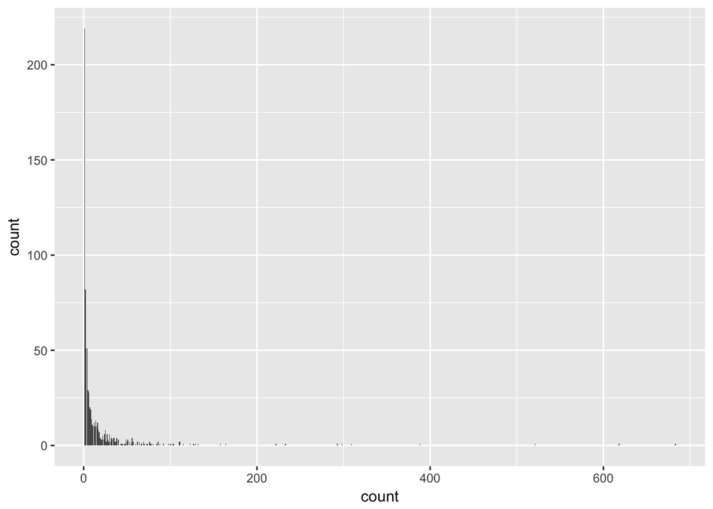

```r
house <- df_books_month_unique %>% group_by(house) %>% summarise(count=n()) %>% arrange(desc(count))
qplot(count, data=house, geom="bar")
```

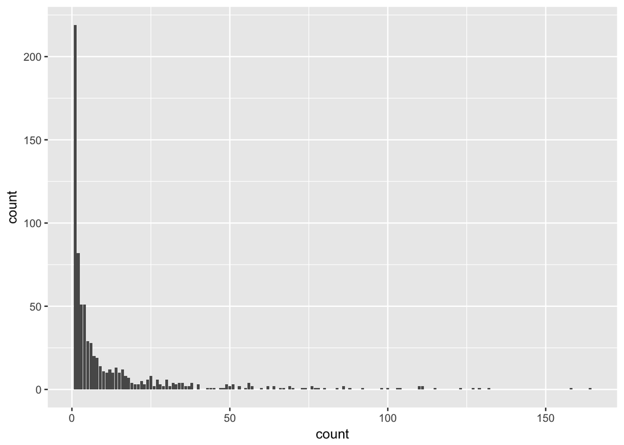

```r
house <- df_books_month_unique %>% group_by(house) %>% summarise(count=n()) %>% arrange(desc(count))%>%filter(count<200)
qplot(count, data=house, geom="bar")
```

大部分的出版進榜書數<50

```r
##上榜的大出版社
house <- df_books_month_unique %>% group_by(house) %>% summarise(count=n()) %>% arrange(desc(count))%>%filter(count>200)
house
```

```
## # A tibble: 9 × 2
##      house count
##     <fctr> <int>
## 1     東立   683
## 2     尖端   618
## 3 台灣角川   521
## 4 時報出版   388
## 5 商周出版   309
## 6     遠流   298
## 7 天下文化   293
## 8     三采   233
## 9     碁峰   222
```

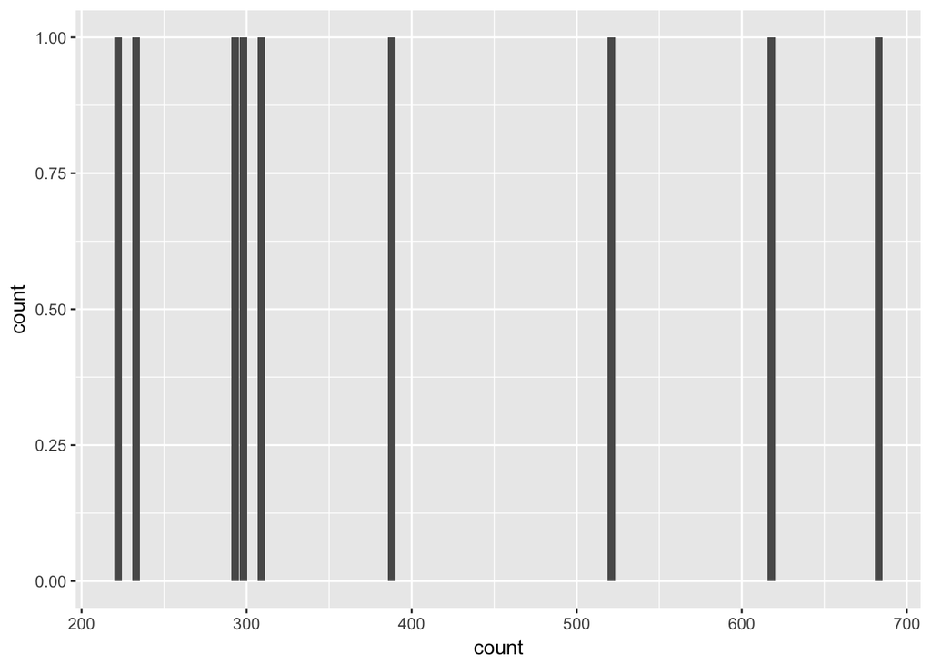

```r
qplot(count, data=house, geom="bar")
```

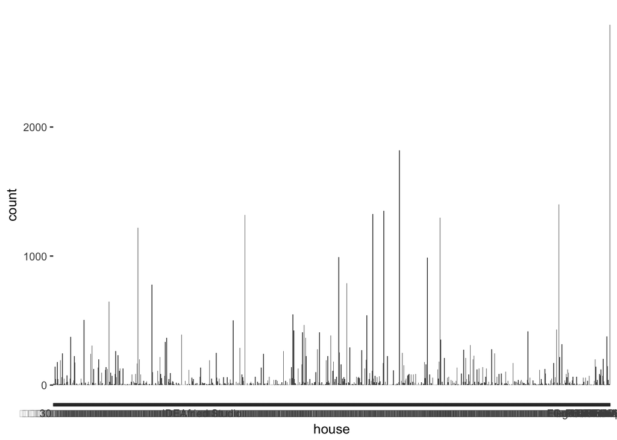

```r
qplot(house, data=month_merge2, geom="bar")
```

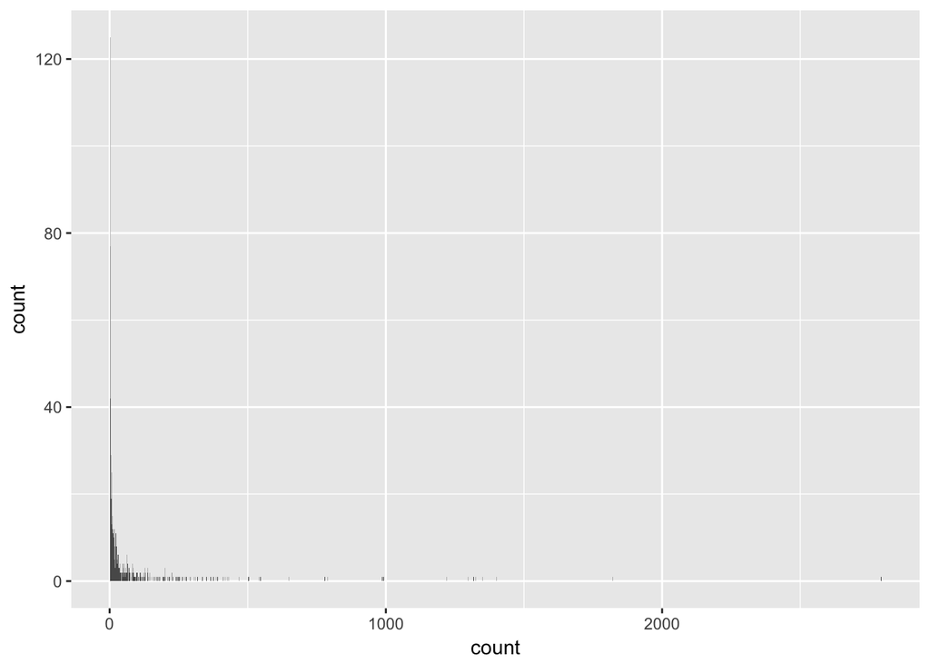

```r
house <- month_merge2 %>% group_by(house) %>% summarise(count=n()) %>% arrange(desc(count))
qplot(count, data=house, geom="bar")
```

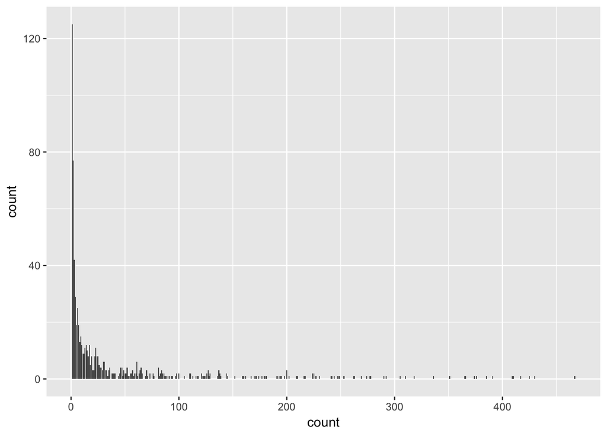

```r
house <- month_merge2 %>% group_by(house) %>% summarise(count=n()) %>% arrange(desc(count)) %>% filter(count<500)
qplot(count, data=house, geom="bar")
```

```r
##重複上榜計算（可能是因為可以一次勁多個榜？->每個類別的相關性）
house <- month_merge2 %>% group_by(house) %>% summarise(count=n()) %>% arrange(desc(count)) %>% filter(count>500)
house
```

```
## # A tibble: 16 × 2
##           house count
##          <fctr> <int>
## 1            NA  2793
## 2      時報出版  1820
## 3          遠流  1399
## 4      商周出版  1349
## 5          三采  1324
## 6          尖端  1318
## 7      天下文化  1297
## 8          東立  1219
## 9          碁峰   992
## 10     台灣角川   987
## 11     親子天下   788
## 12         方智   779
## 13     大塊文化   648
## 14 聯經出版公司   546
## 15         如何   540
## 16     采實文化   504
```

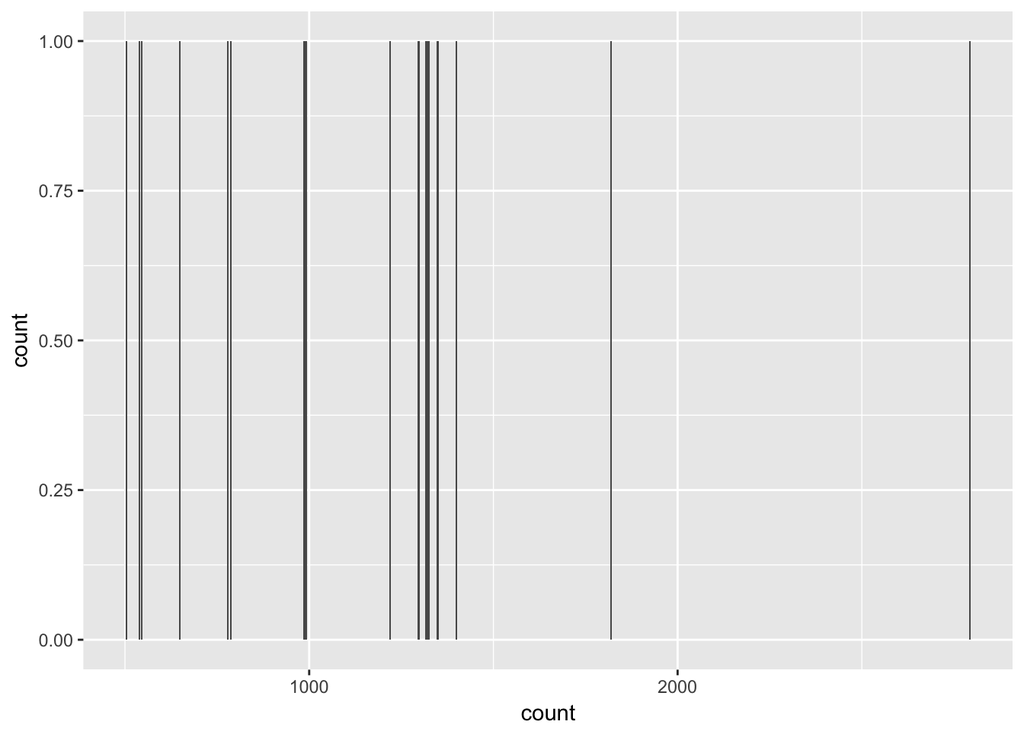

```r
qplot(count, data=house, geom="bar")
```

```r
type_info
```

```
##                 type_name type_id unique_count all_count all_house
## 1                    總榜      00           NA        NA       200
## 2                文學小說      01         1077      4042       122
## 3                商業理財      02          781      3536       108
## 4                藝術設計      03          787      3080       156
## 5                人文史地      04          647      2778       133
## 6                社會科學      05          725      3165       170
## 7                自然科普      06          539      2635       114
## 8                心理勵志      07          647      3722       127
## 9                醫療保健      08          609      3167       132
## 10                   飲食      09          736      2874       127
## 11               生活風格      10          969      4103       169
## 12                   旅遊      11          727      2597       140
## 13               宗教命理      12          644      2452       158
## 14               親子教養      13          490      2939       121
```

[output cut: 29 more lines]

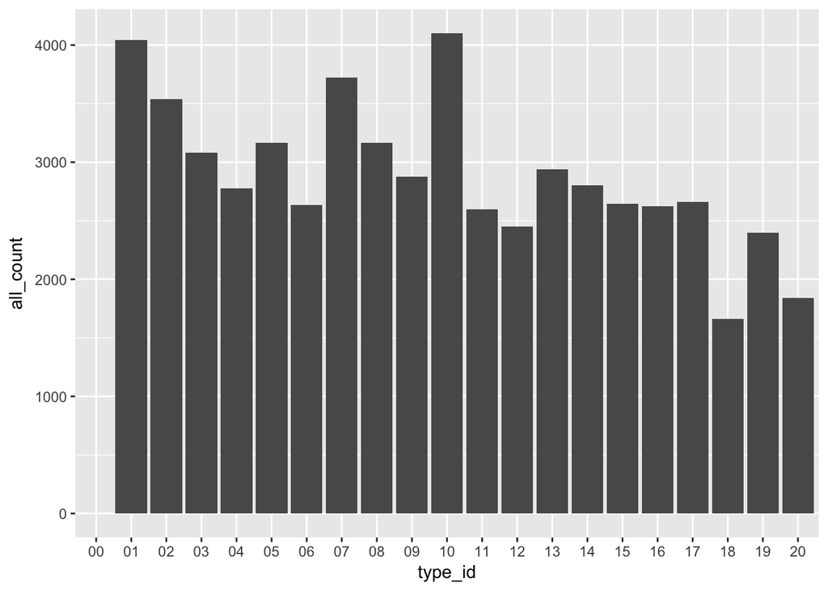

```r
#all_count:all每個類別的書數量
g <- ggplot(type_info,aes(x=type_id,y=all_count))
g + geom_bar(stat = "identity")
```

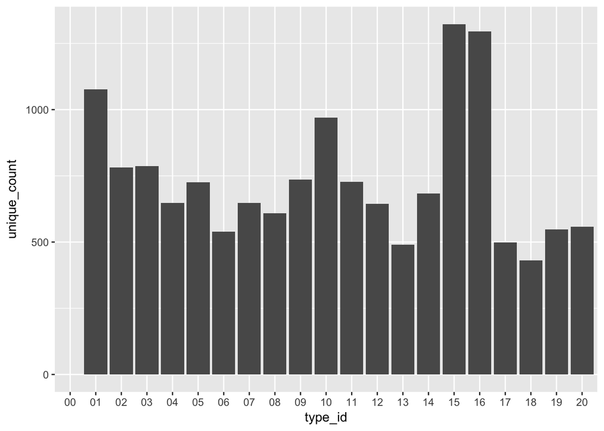

```r
#unique_count:每個類別的書數量
g <- ggplot(type_info,aes(x=type_id,y=unique_count))
g + geom_bar(stat = "identity")
```

```r
type_info %>% select(type_name,type_id,unique_count,all_count,all_house)%>%arrange(desc(all_count)) %>% mutate(patio=all_count/unique_count)
```

```
##                 type_name type_id unique_count all_count all_house
## 1                生活風格      10          969      4103       169
## 2                文學小說      01         1077      4042       122
## 3                心理勵志      07          647      3722       127
## 4                商業理財      02          781      3536       108
## 5                醫療保健      08          609      3167       132
## 6                社會科學      05          725      3165       170
## 7                藝術設計      03          787      3080       156
## 8                親子教養      13          490      2939       121
## 9                    飲食      09          736      2874       127
## 10        童書/青少年文學      14          683      2800        84
## 11               人文史地      04          647      2778       133
## 12               語言學習      17          499      2661        68
## 13                 輕小說      15         1323      2645        33
## 14               自然科普      06          539      2635       114
```

[output cut: 29 more lines]

重附上榜原因：一本書多類別 /上多月榜

# ==========

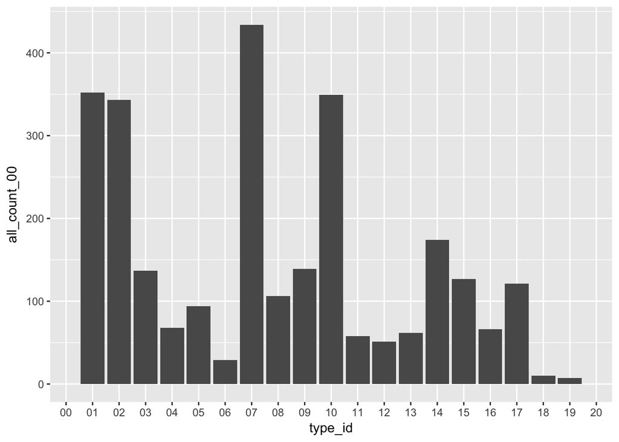

[figure not shown]

```r
##all_count_00:總榜下個類別書數量
g <- ggplot(type_info,aes(x=type_id,y=all_count_00))
g + geom_bar(stat = "identity")
```

```r
type_info %>% select(type_name,type_id,unique_count_00,all_count_00,all_house)%>%arrange(desc(unique_count_00)) %>% mutate(patio=all_count_00/unique_count_00)
```

```
##                 type_name type_id unique_count_00 all_count_00 all_house
## 1                生活風格      10             220          349       169
## 2                文學小說      01             196          352       122
## 3                心理勵志      07             173          434       127
## 4                商業理財      02             165          343       108
## 5                  輕小說      15             110          127        33
## 6                    飲食      09              85          139       127
## 7         童書/青少年文學      14              83          174        84
## 8                藝術設計      03              77          137       156
## 9                語言學習      17              68          121        68
## 10               社會科學      05              59           94       170
## 11                   漫畫      16              54           66        32
## 12               醫療保健      08              51          106       132
## 13                   旅遊      11              41           58       140
## 14               人文史地      04              36           68       133
```

[output cut: 29 more lines]

進總榜： 10(生活風格)、01(文學小說)、07(心理勵志)、02(商業理財) 叫夯 20(專業/教科書/政府出版品)19(電腦資訊)、18(考試用書)、06(自然科普)、12(宗教命理)等很難成為暢銷書 10(生活風格)進總榜書數最多 07(心理勵志)上榜次數最多 比較會重複上榜

15(輕小說)、14(童書/青少年文學)、17(語言學習)集中在固定出版社手中

爬每類共幾本書？？？

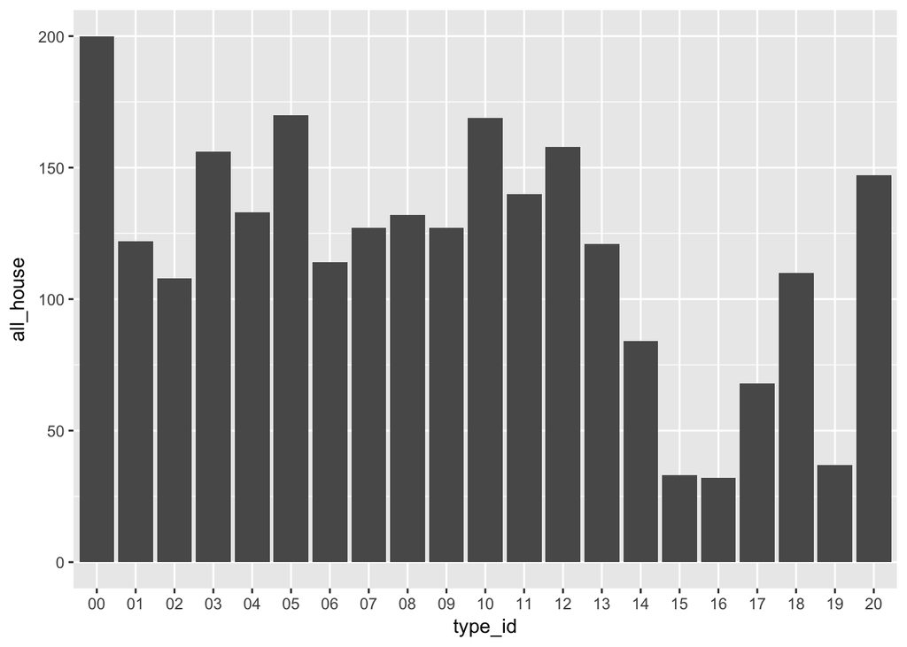

```r
###all_house：進榜的每個類別的house家數
g <- ggplot(type_info,aes(x=type_id,y=all_house))
g + geom_bar(stat = "identity")
```

15(輕小說)、16(漫畫)、19(電腦資訊)出版社較少 05(社會科學)、10(生活風格)、12(宗教命理) 出版社較多 比較競爭？還是因為冷門容易進榜？